# NHANES blood pressure — Linear Regression

T.V.Q (James)

2026-05-12

## 1 Introduction

Linear regression analysis is used to predict the value of a variable (dependent variable) based on the value of another variable(s) (dependent variable(s)) by fitting a linear equation to observed data. This form of analysis estimates the coefficients of the linear equation, involving one or more independent variables.

Systolic blood pressure a clinically important outcome it is the strongest predictor of cardiovascular disease (CVD), mortality, and target organ damage, especially in adults over 50. Elevated SBP represents the force of blood against arterial walls, and its control is critical for reducing stroke, heart failure, and renal failure risk

## 2 Data

The dataset used in this report is the NHANES dataset from `NHANES` package in `R`. It is a subset of the data of a yearly survey conducted by the US National Center for Health Statistics (NCHS) since 1999. The outcome of interest is the Systolic blood pressure and its linear model is fitted against Age, BMI and gender. The reference level for used for gender is female.

The dataset is filtered for adult population (age >= 18) and complete-case analysis of Systolic blood pressure, Age, BMI and gender because of its simplicity and there is no assumption of mechanism of missing data.

```r
# Load the library
library(NHANES)     # For NHANES dataset
library(dplyr)      # For data manipulation
library(ggplot2)    # For graphs
library(patchwork)  # To combine multiple plots into a single layout
library(broom)      # For tidy() function
library(gtsummary)  # For publication-ready regression tables
library(knitr)      # For kable() function
```

```r
nhanes <- NHANES |>
  filter(Age >= 18) |>
  distinct() |>
  filter(!is.na(BPSysAve), !is.na(Age), !is.na(BMI), !is.na(Gender)) |>
  mutate(Gender = factor(Gender, levels = c("female", "male")))
```

## 3 Exploratory Analysis

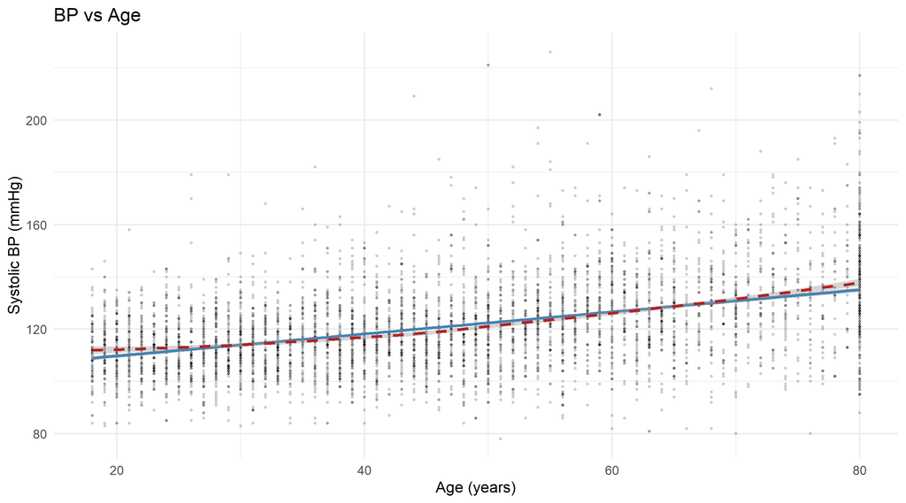

Figure 1. Scatter plot of Systolic BP and Age — NHANES adults (over 18 years old)

```r
# Scatter plot with linear fit and the LOESS curve
#   Variables: BPSysAve vs Age
ggplot(nhanes, aes(x = Age, y = BPSysAve)) +
  geom_point(alpha = 0.15, size = 0.6) +
  geom_smooth(method = "lm", color = "steelblue") +
  geom_smooth(method = "loess", color = "firebrick", linetype = "dashed") +
  labs(title = "BP vs Age", x = "Age (years)", y = "Systolic BP (mmHg)") +
  theme_minimal()
```

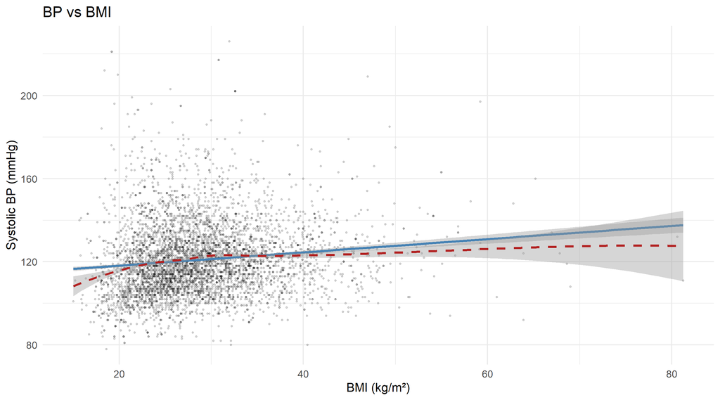

Figure 2. Scatter plot of Systolic BP and BMI — NHANES adults (over 18 years old)

```r
# Scatter plot with linear fit and the LOESS curve
#   Variables: BPSysAve vs BMI
ggplot(nhanes, aes(x = BMI, y = BPSysAve)) +
  geom_point(alpha = 0.15, size = 0.6) +
  geom_smooth(method = "lm", color = "steelblue") +
  geom_smooth(method = "loess", color = "firebrick", linetype = "dashed") +
  labs(title = "BP vs BMI", x = "BMI (kg/m²)", y = "Systolic BP (mmHg)") +
  theme_minimal()
```

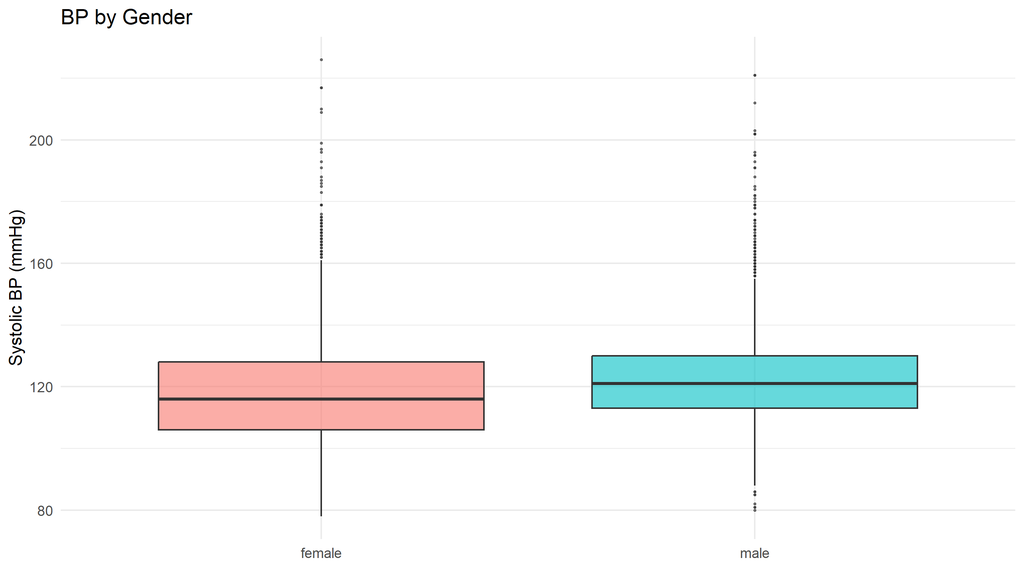

Figure 3. Box plot of Systolic BP by gender — NHANES adults (over 18 years old)

```r
# Box plot
#   Variables: BPSysAve vs BMI
ggplot(nhanes, aes(x = Gender, y = BPSysAve, fill = Gender)) +
  geom_boxplot(alpha = 0.6, outlier.size = 0.5) +
  labs(title = "BP by Gender", x = NULL, y = "Systolic BP (mmHg)") +
  theme_minimal() + theme(legend.position = "none")
```

## 4 Model Comparison

```r
# Build the models
#   Model 1: Age only
m1 <- lm(BPSysAve ~ Age, data = nhanes)

#   Model 2: Age + Gender
m2 <- lm(BPSysAve ~ Age + Gender, data = nhanes)

#   Model 3: Age + Gender + BMI (full model)
m3 <- lm(BPSysAve ~ Age + Gender + BMI, data = nhanes)
```

```r
# Report the summary table
bind_rows(
  glance(m1) |> mutate(model = "M1: Age"),
  glance(m2) |> mutate(model = "M2: Age + Gender"),
  glance(m3) |> mutate(model = "M3: Age + Gender + BMI")
) |>
  select(model, r.squared, adj.r.squared, AIC, BIC) |>
  mutate(across(where(is.numeric), ~ round(., 3)))  |>
  kable(caption = "Table 1. Summary of linear regression models of
        Average Systolic BP against Age, BMI and gender — NHANES adults
              (over 18 years old)",
    col.names = c("Model", "R²", "adjusted R²", "AIC", "BIC")
  )
```

Table 1. Summary of linear regression models of Average Systolic BP against Age, BMI and gender — NHANES adults (over 18 years old)

| Model | R² | adjusted R² | AIC | BIC |
| --- | --- | --- | --- | --- |
| M1: Age | 0.187 | 0.187 | 45073.29 | 45093.07 |
| M2: Age + Gender | 0.206 | 0.205 | 44948.21 | 44974.60 |
| M3: Age + Gender + BMI | 0.215 | 0.215 | 44883.41 | 44916.39 |

The `R²` of model 1 (simple model), 2 and 3 (full model) are 0.187, 0.206, and 0.215, respectively, which means 18.7%, 20.6%. and 21.5% of the variation of Systolic BP is explained by model 1, 2, and 3, respectively.

The full model fits best because it has the higest `R²` and adjusted `R²`

## 5 Coefficient Interpretation

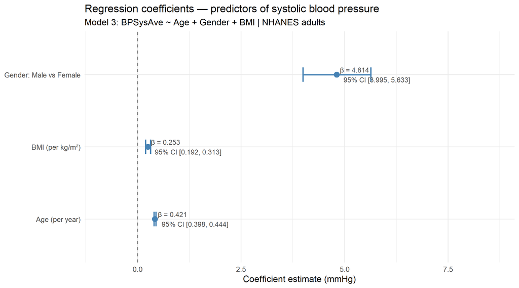

Figure 4. Regression coefficients — predictors of systolic blood pressure — NHANES adults (over 18 years old)

```r
# Round all numeric columns in smmary table of model 3 to 3 decimal places
m3_tidy <- tidy(m3, conf.int = TRUE) |>
  mutate(across(where(is.numeric) & !p.value, ~ round(., 3))) |>
  mutate(p.value = format.pval(p.value, digits = 3))

# Coefficient plot
m3_tidy |>
  filter(term != "(Intercept)") |>  # Remove the row of the intercept
  mutate(term = recode(term,
    "Age"        = "Age (per year)",
    "Gendermale" = "Gender: Male vs Female",
    "BMI"        = "BMI (per kg/m²)"
  )) |>
  ggplot(aes(x = estimate, y = term)) +
  geom_vline(xintercept = 0, linetype = "dashed", color = "grey50") +
  geom_errorbar(aes(xmin = conf.low, xmax = conf.high), orientation = "y",
                height = 0.2, linewidth = 0.8, color = "steelblue") +
  geom_point(size = 3, color = "steelblue") +
  geom_text(aes(label = paste0("β = ", estimate, "\n95% CI [",
      conf.low, ", ", conf.high, "]"
    )), hjust = -0.1, size = 3, color = "grey30"
  ) +
  labs(
    title   = "Regression coefficients — predictors of systolic blood pressure",
    subtitle = "Model 3: BPSysAve ~ Age + Gender + BMI | NHANES adults",
    x        = "Coefficient estimate (mmHg)",
    y        = NULL
  ) +
  theme_minimal() +
  xlim(min(m3_tidy$conf.low[m3_tidy$term != "(Intercept)"], na.rm = TRUE) - 1,
       max(m3_tidy$conf.high[m3_tidy$term != "(Intercept)"], na.rm = TRUE) + 3)
```

- Holding all other variables constant, a one-unit increase in Age is associated with a 0.421 mmHg increase in systolic BP (95% CI: [0.398, 0.444], p < 2e-16)
- Holding all other variables constant, a one-unit increase in BMI is associated with a 0.253 mmHg increase in systolic BP (95% CI: [0.192, 0.313], p = 3.09e-16)
- Males have, on average, 4.81 mmHg higher systolic BP than females of the same age and BMI (95% CI: [4.00 , 5.63], p < 2e-16)

All variables (Age, BMI, and gender) are statistically significant

## 6 Assumption Checks

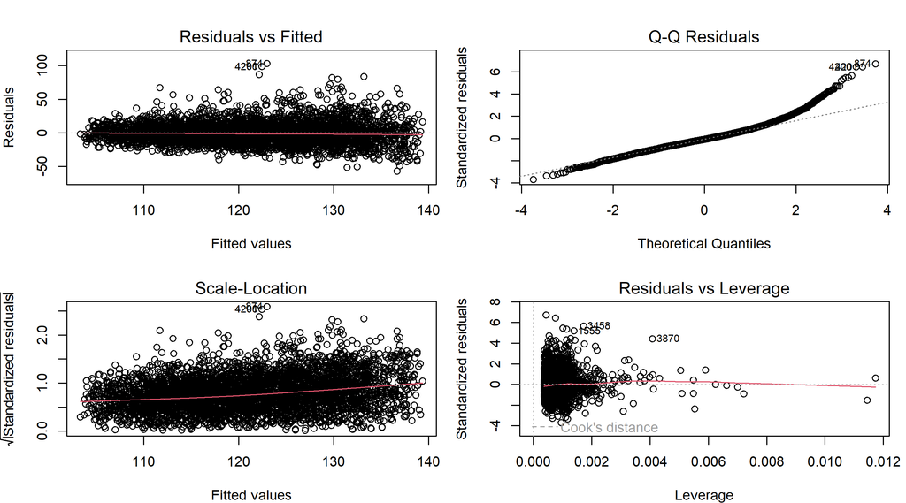

Figure 5. Assumption plots for linear regression of Systolic blood pressure — NHANES adults (over 18 years old)

```r
par(mfrow = c(2, 2), mar = c(4, 4, 3, 1))
plot(m3)
```

## 7 Predicted Effects

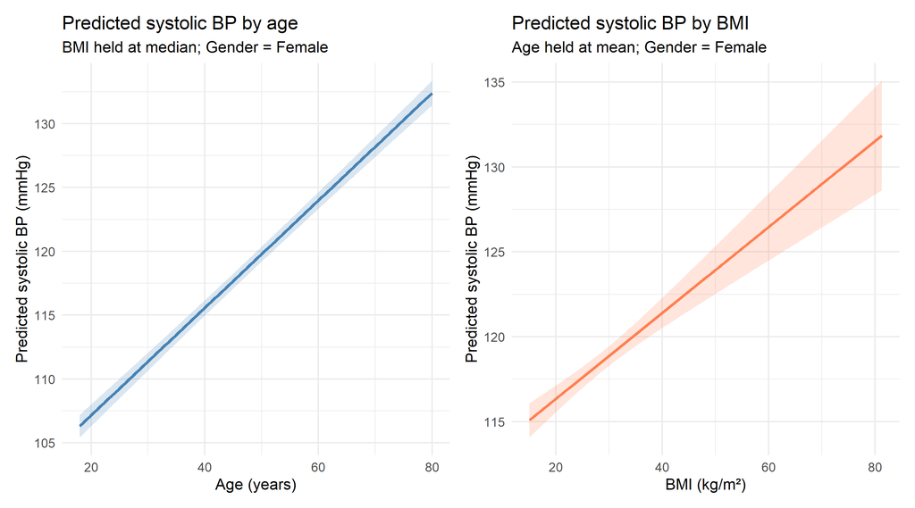

Figure 6. Predicted effects plots of Systolic blood pressure — NHANES adults (over 18 years old)

```r
# Create a prediction grid for Age (holding BMI at median, Gender = female)
age_grid <- data.frame(
  Age    = seq(min(nhanes$Age), max(nhanes$Age), length.out = 100),
  BMI    = median(nhanes$BMI),
  Gender = factor("female", levels = c("female", "male"))
)


age_pred <- predict(m3, newdata = age_grid, interval = "confidence") |>
  as.data.frame() |>
  bind_cols(age_grid)


p_partial_age <- ggplot(age_pred, aes(x = Age)) +
  geom_ribbon(aes(ymin = lwr, ymax = upr), fill = "steelblue", alpha = 0.2) +
  geom_line(aes(y = fit), color = "steelblue", linewidth = 1) +
  labs(
    title    = "Predicted systolic BP by age",
    subtitle = "BMI held at median; Gender = Female",
    x        = "Age (years)", y = "Predicted systolic BP (mmHg)"
  ) +
  theme_minimal()

# Repeat for BMI (holding Age at mean, Gender = female)
bmi_grid <- data.frame(
  BMI    = seq(min(nhanes$BMI), max(nhanes$BMI), length.out = 100),
  Age    = mean(nhanes$Age),
  Gender = factor("female", levels = c("female", "male"))
)

bmi_pred <- predict(m3, newdata = bmi_grid, interval = "confidence") |>
  as.data.frame() |>
  bind_cols(bmi_grid)

p_partial_bmi <- ggplot(bmi_pred, aes(x = BMI)) +
  geom_ribbon(aes(ymin = lwr, ymax = upr), fill = "coral", alpha = 0.2) +
  geom_line(aes(y = fit), color = "coral", linewidth = 1) +
  labs(
    title    = "Predicted systolic BP by BMI",
    subtitle = "Age held at mean; Gender = Female",
    x        = "BMI (kg/m²)", y = "Predicted systolic BP (mmHg)"
  ) +
  theme_minimal()

# Plot the figures
p_partial_age | p_partial_bmi
```

## 8 Publication Table

```r
tbl_regression(m3,
  label = list(
    Age        ~ "Age (years)",
    Gender     ~ "Gender",
    BMI        ~ "BMI (kg/m²)"
  )
) |>
  add_glance_source_note(
    label = list(r.squared ~ "R²", adj.r.squared ~ "Adjusted R²"),
    include = c(r.squared, adj.r.squared, nobs)
  ) |>
  bold_p(t = 0.05) |>
  bold_labels()
```

| **Characteristic** | **Beta** | **95% CI** | **p-value** |
| --- | --- | --- | --- |
| Age (years) | 0.42 | 0.40, 0.44 | <0.001 |
| Gender |  |  |  |
| female | — | — |  |
| male | 4.8 | 4.0, 5.6 | <0.001 |
| BMI (kg/m²) | 0.25 | 0.19, 0.31 | <0.001 |

Abbreviation: CI = Confidence Interval  
R² = 0.215; Adjusted R² = 0.215; No. Obs. = 5,408

21.5% of the variation of Systolic BP is explained by lineal model including Age, BMI and gender

## 9 Limitations

There are several Limitations with this analysis: * The linearity assumptions are not fulfilled totally. The Normality assumption might not be fulfilled as the normal model does not accurately describe the heavy tail (right-skewed) of data

- The linear model only assess 3 variables without considering interaction or other confounders.
- The dataset is a cross-sectional survey, it cannot hold any conclusion for the trend of the effects over time.

## 10 Bonus: Test whether the relationship between Age and BP is non-linear

```r
# Create a column of the quadratic term of Age
nhanes <- nhanes |> mutate(Age2 = Age^2)

# Model 4: Age + Gender + BMI + Age²
m4 <- lm(BPSysAve ~ Age + Age2 + Gender + BMI, data = nhanes)

# Compare M3 vs M4 with a likelihood ratio test
anova(m3, m4)
```

|  | Res.Df | RSS | Df | Sum of Sq | F | Pr(>F) |
| --- | --- | --- | --- | --- | --- | --- |
| 1 | 5404 | 1271052 | NA | NA | NA | NA |
| 2 | 5403 | 1255473 | 1 | 15578.76 | 67.04406 | 3.283368e-16 |

With p-value of 3.283e-16, adding the quadratic term of Age contribute significantly to the model including Age, BMI and gender. Therefore, relationship between Age and Systolic BP is non-linear